# Advanced-Statistics-With-R

## 1.1 Comparing Two Correlation Coefficients

### 1.1.1 Comparing Correlations In Two Independent Groups

- Fisher’s z transformation can be used to test hypotheses or form confidence intervals about the difference between the correlations between the same two variables in two independent groups. The results of such tests are also called independent correlations.

```r
# Summary statistics for sex in Fat_data.
Fat_data%>%
  dplyr::group_by(Sex)%>%
  rstatix::get_summary_stats(BMI, Percent.Fat, type = "mean_sd")
```

| Sex | variable | n | mean | sd |
| --- | --- | --- | --- | --- |
| F | BMI | 71 | 23.392 | 3.803 |
| F | Percent.Fat | 71 | 32.279 | 6.538 |
| M | BMI | 40 | 24.535 | 3.690 |
| M | Percent.Fat | 40 | 21.358 | 7.839 |

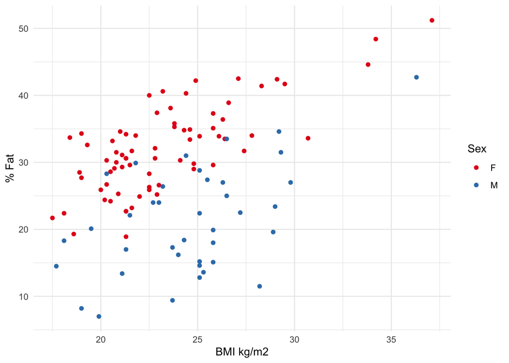

```r
# Visualize BMI and percent fat correlations with genders.

ggplot(data=Fat_data, aes(x=BMI,y=Percent.Fat,color=Sex))+
  geom_point()+
  xlab("BMI kg/m2")+
  ylab("% Fat")+
  theme_minimal()+
  scale_color_brewer(palette = "Set1")
```

```r
# The correlation between BMI and percent body fat  the 71 female subjects
cor.test(x=Fat_data[Fat_data$Sex=="F","BMI"],
         y=Fat_data[Fat_data$Sex=="F","Percent.Fat"],
    method="pearson",
    alternative = "two.sided",
    conf.level = 0.95)
```

```
##
##  Pearson's product-moment correlation
##
## data:  Fat_data[Fat_data$Sex == "F", "BMI"] and Fat_data[Fat_data$Sex == "F", "Percent.Fat"]
## t = 9.0585, df = 69, p-value = 2.336e-13
## alternative hypothesis: true correlation is not equal to 0
## 95 percent confidence interval:
##  0.6083332 0.8279656
## sample estimates:
##       cor
## 0.7370326
```

```r
# The correlation between BMI and percent body fat  the 40 male subjects

cor.test(x=Fat_data[Fat_data$Sex=="M","BMI"],
         y=Fat_data[Fat_data$Sex=="M","Percent.Fat"],
    method="pearson",
    alternative = "two.sided",
    conf.level = 0.95)
```

```
##
##  Pearson's product-moment correlation
##
## data:  Fat_data[Fat_data$Sex == "M", "BMI"] and Fat_data[Fat_data$Sex == "M", "Percent.Fat"]
## t = 3.6346, df = 38, p-value = 0.000821
## alternative hypothesis: true correlation is not equal to 0
## 95 percent confidence interval:
##  0.2333051 0.7074769
## sample estimates:
##       cor
## 0.5079018
```

```r
# Using cocor package to compare correlations of independent groups.
suppressMessages(library(cocor))
male_data=Fat_data[Fat_data$Sex=="M",]
female_data=Fat_data[Fat_data$Sex=="F",]
cocor(~BMI+Percent.Fat|BMI+Percent.Fat,
      data=list(female_data, male_data),
      alternative = "two.sided",
      alpha = 0.05)
```

```
##
##   Results of a comparison of two correlations based on independent groups
##
## Comparison between r1.jk (BMI, Percent.Fat) = 0.737 and r2.hm (BMI, Percent.Fat) = 0.5079
## Difference: r1.jk - r2.hm = 0.2291
## Data: list(female_data, male_data): j = BMI, k = Percent.Fat, h = BMI, m = Percent.Fat
## Group sizes: n1 = 71, n2 = 40
## Null hypothesis: r1.jk is equal to r2.hm
## Alternative hypothesis: r1.jk is not equal to r2.hm (two-sided)
## Alpha: 0.05
##
## fisher1925: Fisher's z (1925)
##   z = 1.8800, p-value = 0.0601
##   Null hypothesis retained
##
## zou2007: Zou's (2007) confidence interval
##   95% confidence interval for r1.jk - r2.hm: -0.0083 0.5184
##   Null hypothesis retained (Interval includes 0)
```

```r
# We do not reject the null hypothesis of equal correlations.
# There is no statistical evidence to conclude that -->
# the relationship between BMI and body fat percentage is different for
# men and women.
```

- When the research question involves correlations that contain the same variable (also called dependent correlations).
- Pereira and colleagues (2015) was whether one of the bedside glucose devices was more highly correlated with the arterial central lab value than the other two. We compare the blood glucose with Accu-check arterial measure and the arterial central lab value to the blood glucose with the Accu-check finger stick and the arterial central lab value.
- There are several formulas for testing the difference between two dependent correlations. We present the simplest one, developed by Hotelling (1940) and described by Glass and Stanley (1970).

```r
# Data preperation
glucose_data<-data.frame(
  readxl::read_xls("Data bank_19052015.xls")
  )[,c("Arterial.central.lab..mg.dL.",
       "Accu.chek.arterial..mg.dL.",
       "Accu.chek.fingerstick..mg.dL.",
       "Accu.chek.central.venous.catheter..mg.dL.")]
colnames(glucose_data)<-c("Arterial.Central.Lab",
                          "Accu.Arterial",
                          "Accu.Fingerstick",
                          "Accu.CVC")

# Descriptive statistics from Hmisc package
Hmisc::describe(glucose_data)
```

```
## glucose_data
##
##  4  Variables      145  Observations
## --------------------------------------------------------------------------------
## Arterial.Central.Lab
##        n  missing distinct     Info     Mean      Gmd      .05      .10
##      145        0       93        1    145.7    70.81     75.0     87.8
##      .25      .50      .75      .90      .95
##    101.0    126.0    161.0    213.0    271.0
##
## lowest :  51  69  70  72  74, highest: 337 338 355 379 974
## --------------------------------------------------------------------------------
## Accu.Arterial
##        n  missing distinct     Info     Mean      Gmd      .05      .10
##      145        0       98        1    151.1    65.74     84.6     92.4
##      .25      .50      .75      .90      .95
##    111.0    131.0    169.0    230.0    285.0
##
## lowest :  72  77  78  83  84, highest: 349 360 384 409 513
## --------------------------------------------------------------------------------
## Accu.Fingerstick
##        n  missing distinct     Info     Mean      Gmd      .05      .10
##      145        0      102        1      151    68.41     83.2     91.0
##      .25      .50      .75      .90      .95
##    108.0    131.0    174.0    224.4    271.8
##
## lowest :  66  67  78  80  81, highest: 352 401 405 406 600
## --------------------------------------------------------------------------------
## Accu.CVC
##        n  missing distinct     Info     Mean      Gmd      .05      .10
##      144        1       97        1    161.6    82.07     85.3     94.3
##      .25      .50      .75      .90      .95
##    111.8    134.0    183.8    259.5    329.9
##
## lowest :  30  75  78  83  84, highest: 352 357 417 580 600
## --------------------------------------------------------------------------------
```

```r
# One row has missing data
# Removing missing data
glucose_data<-glucose_data[complete.cases(glucose_data),]
head(glucose_data,10)
```

|  | Arterial.Central.Lab | Accu.Arterial | Accu.Fingerstick | Accu.CVC |
| --- | --- | --- | --- | --- |
| 1 | 186 | 198 | 207 | 195 |
| 2 | 202 | 227 | 221 | 221 |
| 3 | 115 | 127 | 125 | 135 |
| 4 | 155 | 152 | 161 | 142 |
| 5 | 124 | 137 | 130 | 119 |
| 6 | 193 | 182 | 196 | 190 |
| 7 | 165 | 192 | 175 | 188 |
| 8 | 130 | 136 | 128 | 331 |
| 9 | 92 | 83 | 92 | 84 |
| 10 | 129 | 125 | 111 | 129 |

```r
# Rstatix package get summary statistics
get_summary_stats(glucose_data)
```

| variable | n | min | max | median | q1 | q3 | iqr | mad | mean | sd | se | ci |
| --- | --- | --- | --- | --- | --- | --- | --- | --- | --- | --- | --- | --- |
| Accu.Arterial | 144 | 72 | 513 | 131.5 | 111.00 | 169.25 | 58.25 | 39.289 | 151.222 | 68.757 | 5.730 | 11.326 |
| Accu.CVC | 144 | 30 | 600 | 134.0 | 111.75 | 183.75 | 72.00 | 45.961 | 161.597 | 90.210 | 7.517 | 14.860 |
| Accu.Fingerstick | 144 | 66 | 600 | 130.5 | 107.50 | 174.25 | 66.75 | 42.995 | 151.090 | 73.875 | 6.156 | 12.169 |
| Arterial.Central.Lab | 144 | 51 | 974 | 126.5 | 101.00 | 161.25 | 60.25 | 40.771 | 145.931 | 91.476 | 7.623 | 15.068 |

```r
# Creating correlation matrix using Rstatix package
cor_mat(glucose_data,
                 method = "pearson",
                 alternative = "two.sided",
                 conf.level = .95)
```

|  | rowname | Arterial.Central.Lab | Accu.Arterial | Accu.Fingerstick | Accu.CVC |
| --- | --- | --- | --- | --- | --- |
| 1 | Arterial.Central.Lab | 1.00 | 0.57 | 0.87 | 0.78 |
| 2 | Accu.Arterial | 0.57 | 1.00 | 0.67 | 0.71 |
| 3 | Accu.Fingerstick | 0.87 | 0.67 | 1.00 | 0.70 |
| 4 | Accu.CVC | 0.78 | 0.71 | 0.70 | 1.00 |

```r
# Significance levels
cor_mat(glucose_data,
                 method = "pearson",
                 alternative = "two.sided",
                 conf.level = .95)%>%cor_get_pval()
```

| rowname | Arterial.Central.Lab | Accu.Arterial | Accu.Fingerstick | Accu.CVC |
| --- | --- | --- | --- | --- |
| Arterial.Central.Lab | 0.00e+00 | 9.18e-14 | 6.65e-45 | 1.14e-30 |
| Accu.Arterial | 9.18e-14 | 0.00e+00 | 8.07e-20 | 2.29e-23 |
| Accu.Fingerstick | 6.65e-45 | 8.07e-20 | 0.00e+00 | 3.83e-22 |
| Accu.CVC | 1.14e-30 | 2.29e-23 | 3.83e-22 | 0.00e+00 |

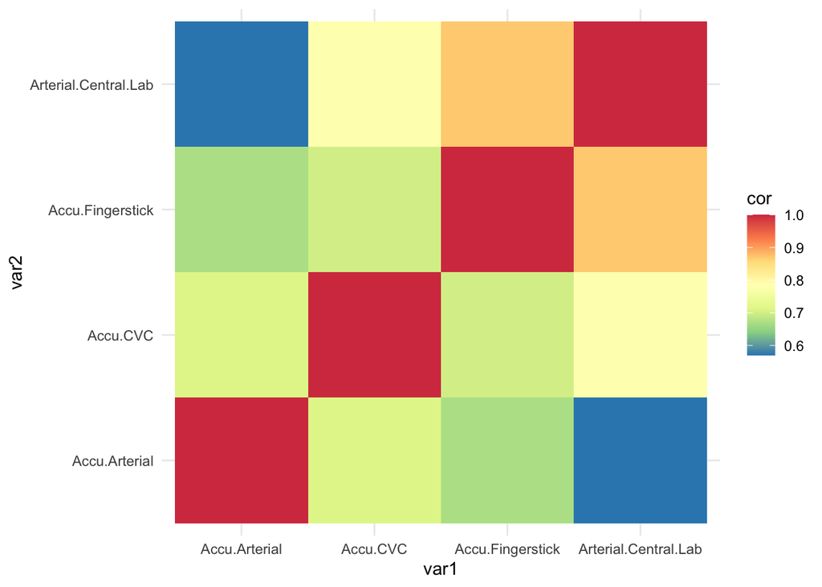

```r
# Creating long format data to summarize r values and p values together
long_format<-cor_gather(cor_mat(glucose_data))

# Crating heatmap with long format table
ggplot(data=long_format, aes(x=var1,y=var2, fill=cor))+
  geom_tile()+
  scale_fill_distiller(palette = "Spectral")+
  theme_minimal()
```

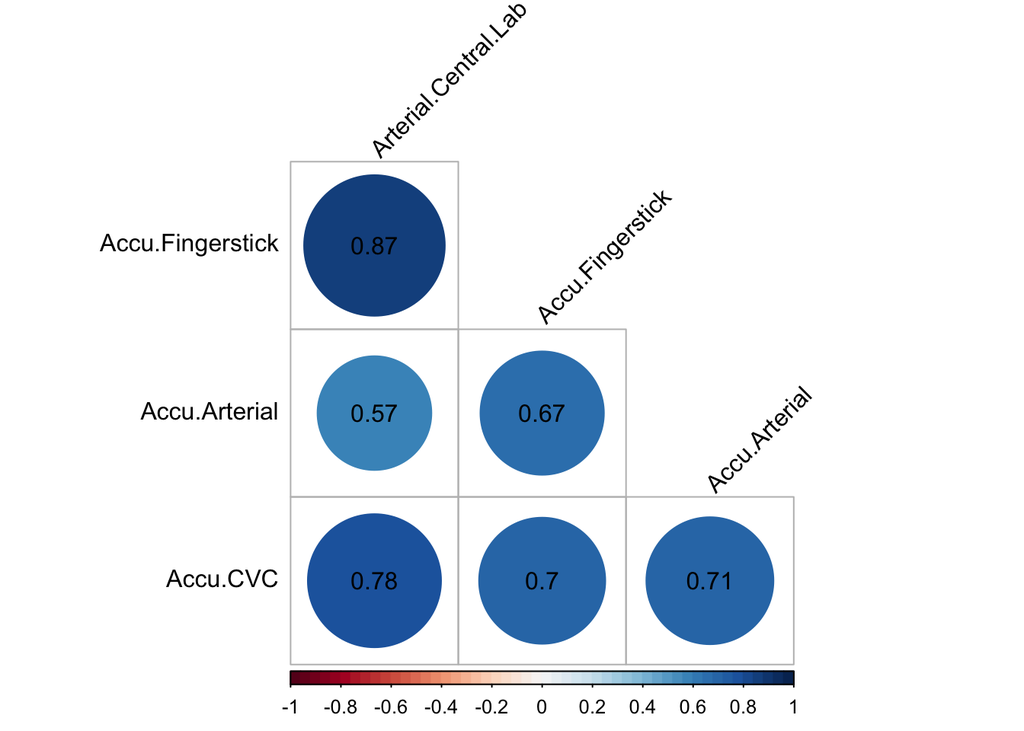

```r
# Correlation plot with rstatix package
cor_mat(glucose_data,
                 method = "pearson",
                 alternative = "two.sided",
                 conf.level = .95) %>%
  cor_reorder()%>% # Reorder correlation matrix,
  # according to the coefficients, using the hierarchical clustering method.
  pull_lower_triangle()%>%
  cor_plot(method = "circle",
           insignificant = "blank",
           label = TRUE,
           significant.level = 0.001,
           palette = ggpubr::get_palette("RdBu",50))
```

```r
# Calculations for comparing correlations based on dependent groups
# When the correlations are overlapping
# H0= Correlation between Accu.Arterial method and Gold standard method is
# Equal to correlation between Accu.Fingerstick method and Gold standard method
suppressMessages(library(cocor))
cocor(~Accu.Arterial + Arterial.Central.Lab|
      Accu.Fingerstick + Arterial.Central.Lab ,
      data = glucose_data,
      test=c("hotelling1940","hendrickson1970")
      # or we can use test = c("silver2004", "zou2007")
      )
```

```
##
##   Results of a comparison of two overlapping correlations based on dependent groups
##
## Comparison between r.jk (Arterial.Central.Lab, Accu.Arterial) = 0.5697 and r.jh (Arterial.Central.Lab, Accu.Fingerstick) = 0.8675
## Difference: r.jk - r.jh = -0.2978
## Related correlation: r.kh = 0.6662
## Data: glucose_data: j = Arterial.Central.Lab, k = Accu.Arterial, h = Accu.Fingerstick
## Group size: n = 144
## Null hypothesis: r.jk is equal to r.jh
## Alternative hypothesis: r.jk is not equal to r.jh (two-sided)
## Alpha: 0.05
##
## hotelling1940: Hotelling's t (1940)
##   t = -8.7021, df = 141, p-value = 0.0000
##   Null hypothesis rejected
##
## hendrickson1970: Hendrickson, Stanley, and Hills' (1970) modification of Williams' t (1959)
##   t = -8.7020, df = 141, p-value = 0.0000
##   Null hypothesis rejected
```

```r
# Another option is to use correlation values directly.
cocor.dep.groups.overlap(r.jk = 0.57, # Accu.Arterial + Arterial.Central.Lab
                         r.jh = 0.87, # Accu.Fingerstick + Arterial.Central.Lab
                         r.kh = 0.67, # Accu.Arterial + Accu.Fingerstick
                         n=144,
                         test = "hotelling1940",
                         alternative = "two.sided"
                         )
```

```
##
##   Results of a comparison of two overlapping correlations based on dependent groups
##
## Comparison between r.jk = 0.57 and r.jh = 0.87
## Difference: r.jk - r.jh = -0.3
## Related correlation: r.kh = 0.67
## Group size: n = 144
## Null hypothesis: r.jk is equal to r.jh
## Alternative hypothesis: r.jk is not equal to r.jh (two-sided)
## Alpha: 0.05
##
## hotelling1940: Hotelling's t (1940)
##   t = -8.8989, df = 141, p-value = 0.0000
##   Null hypothesis rejected
```

```r
# The difference between these two correlations is statistically significant.
```

## 1.2 Other Measures of Correlation

### 1.2.1 Spearman’s Rho

- Value of the correlation coefficient is markedly influenced by extreme values and thus does not provide a good description of the relationship between two variables when their distributions are skewed or contain outlying values.
- Plotting values against a normal distribution to help researchers decide whether a nonparametric procedure should be used.

```r
# === CHEKKING FOR NORMALITY ===
# Review arterial glucose measurement data.
head(glucose_data,5)
```

|  | Arterial.Central.Lab | Accu.Arterial | Accu.Fingerstick | Accu.CVC |
| --- | --- | --- | --- | --- |
| 1 | 186 | 198 | 207 | 195 |
| 2 | 202 | 227 | 221 | 221 |
| 3 | 115 | 127 | 125 | 135 |
| 4 | 155 | 152 | 161 | 142 |
| 5 | 124 | 137 | 130 | 119 |

```
## $`1`
```

[figure not shown]

```
##
## $`2`
```

[figure not shown]

```
##
## attr(,"class")
## [1] "list"      "ggarrange"
```

```r
# 1. Creating QQ plot with ggpubr library.

# Create a list to store plots.
hist_list=list()
# Store plots in the list using for loop.
for (column in 1:ncol(glucose_data)) {
  # Creating histograms
  # Histograms will be the 1st, 3rd.. (2n-1) th item in the list.
  hist_list[[(column*2)-1]] = ggplot(data=NULL,aes(x=glucose_data[,column]))+
    geom_histogram(binwidth = 20,
                   color = "black",
                   fill = "darkgoldenrod3")+
    labs(x="Glucose Measurement (mg/dL)",
         title = colnames(glucose_data)[column])+
    theme_few()
  # Creating qqplots.
  # QQ plots will be the 2nd, 4th.. (2n)th item in the list.
  hist_list[[column*2]] = ggqqplot(data = glucose_data,
                                   x=colnames(glucose_data)[column],
                                   combine = TRUE,
                                   shape = 1,
                                   add = "qqline",
                                   xlab = "Normal Quantiles",
                                   ylab = "Sample Vlues")+
    theme_minimal()
}
# Combine plots with ggarrange function in ggpubr.
ggarrange(plotlist = hist_list,
          labels = NULL,
          font.label = list(size=4),
          ncol = 2,
          nrow = 2)
```

```r
# Points at the end of the QQ plot are not falling on a straight line.
# They are scattered significantly.
# All the variables appears to be right skewed.

# Checking for normality assumptions.
# As an example only on one variable (Arterial.Central.Lab)
# In real life check all the variables.
# OUTLIERS
colnames(glucose_data)
```

```
## [1] "Arterial.Central.Lab" "Accu.Arterial"        "Accu.Fingerstick"
## [4] "Accu.CVC"
```

```r
identify_outliers(data.frame(glucose_data$Arterial.Central.Lab))
```

| glucose_data.Arterial.Central.Lab | is.outlier | is.extreme |
| --- | --- | --- |
| 259 | TRUE | FALSE |
| 974 | TRUE | TRUE |
| 289 | TRUE | FALSE |
| 337 | TRUE | FALSE |
| 254 | TRUE | FALSE |
| 355 | TRUE | TRUE |
| 314 | TRUE | FALSE |
| 379 | TRUE | TRUE |
| 274 | TRUE | FALSE |
| 338 | TRUE | FALSE |

```r
# NORMALITY
shapiro_test(glucose_data$Arterial.Central.Lab)
```

| variable | statistic | p.value |
| --- | --- | --- |
| glucose_data$Arterial.Central.Lab | 0.566902 | 7.579439e-19 |

```r
# Arterial.Central.Lab values do not normally distributed.
```

- A simple method for dealing with the problem of extreme observations in correlation is to rank order the data and then recalculate the correlation on ranks to obtain the nonparametric correlation called Spearman’s rho, or rank. correlation.

- The Spearman correlation coefficient is defined as Pearson correlation coefficient between the rank variables.

```r
# The correlation between the arterial central lab value and,
# the Accu-chek finge rstick device
# Using Spearman's rho, or rank-correlation.
# H0: The population value of Spearman's rho is = 0.
# H1: The population value of Spearman's rho is not 0.
rstatix::cor_test(data = glucose_data[1:25,],
                  Arterial.Central.Lab,
                  Accu.Fingerstick,
                  alternative = "two.sided",
                  method = "spearman",
                  use = "all.obs") # or "complete.obs"
```

| var1 | var2 | cor | statistic | p | method |
| --- | --- | --- | --- | --- | --- |
| Arterial.Central.Lab | Accu.Fingerstick | 0.95 | 123.118 | 2.21e-13 | Spearman |

```r
# Or
cor.test(glucose_data[1:25,"Arterial.Central.Lab"],
         glucose_data[1:25,"Accu.Fingerstick"],method = "spearman")
```

```
##
##  Spearman's rank correlation rho
##
## data:  glucose_data[1:25, "Arterial.Central.Lab"] and glucose_data[1:25, "Accu.Fingerstick"]
## S = 123.12, p-value = 2.21e-13
## alternative hypothesis: true rho is not equal to 0
## sample estimates:
##       rho
## 0.9526469
```

```r
# We reject the null hypothesis and conclude:
# There is sufficient evidence that -->
# A nonparametric correlation exists between the blood glucose measurements
# made by the lab test and the fingerstick device.

# ====Important Note====
# method="spearman" is not a good choice for tied ranks.
# In the case of tied ranks kendall method could be used.

# Another Method
# Convert values to rank
ranked_glucose_data<-apply(X=-glucose_data[1:25,],
                          # "-" will ensure highest values to have lowest rank
                          MARGIN = 2,
                          FUN = rank, ties.method="average" )%>%data.frame()

cor.test(ranked_glucose_data$Arterial.Central.Lab,
         ranked_glucose_data$Accu.Fingerstick,
         method="pearson")
```

```
##
##  Pearson's product-moment correlation
##
## data:  ranked_glucose_data$Arterial.Central.Lab and ranked_glucose_data$Accu.Fingerstick
## t = 15.025, df = 23, p-value = 2.21e-13
## alternative hypothesis: true correlation is not equal to 0
## 95 percent confidence interval:
##  0.8940573 0.9791907
## sample estimates:
##       cor
## 0.9526469
```

- To summarize, Spearman’s rho is appropriate when investigators want to measure the relationship between: (1) two ordinal variables, or (2) two numerical variables when one or both are not normally distributed and investigators choose not to use a data transformation (such as taking the logarithm). - Spearman’s rank correlation is especially appropriate when outlying values occur among the observations.

# 2 Confidence Interval For The Odds Ratio and Relavie Risk

- The relative risk (or risk ratio) and the odds ratio as measures of relationship between two nominal characteristics.

```r
# ===ODDS RATIO CALCULATION====
# Create a table to calculate odds ratio.
# Benzodiazepine use and Alzheimer's disease association.
Benzodiazepine.Data<- as.table(cbind(c(894,902),c(2873,4311)))
dimnames(Benzodiazepine.Data) <- list(
  "Benzodiazepine Group"=c("Used", "Never Used"),
  "Patient Group"=c("With Alzheimer's", "Without Alzheimer's"))
Benzodiazepine.Data
```

```
##                     Patient Group
## Benzodiazepine Group With Alzheimer's Without Alzheimer's
##           Used                    894                2873
##           Never Used              902                4311
```

```r
# Calculation of the odds ratio epitools package
library(epitools)
oddsratio(Benzodiazepine.Data,
          rev = "both",# To fit the required column/row format
          correction = FALSE,
          verbose = TRUE, # To get detailed output
          method = "midp")
```

```
## $x
##                     Patient Group
## Benzodiazepine Group Without Alzheimer's With Alzheimer's
##           Never Used                4311              902
##           Used                      2873              894
##
## $data
##                     Patient Group
## Benzodiazepine Group Without Alzheimer's With Alzheimer's Total
##           Never Used                4311              902  5213
##           Used                      2873              894  3767
##           Total                     7184             1796  8980
##
## $p.exposed
##                     Patient Group
## Benzodiazepine Group Without Alzheimer's With Alzheimer's     Total
##           Never Used           0.6000835        0.5022272 0.5805122
##           Used                 0.3999165        0.4977728 0.4194878
##           Total                1.0000000        1.0000000 1.0000000
##
## $p.outcome
##                     Patient Group
## Benzodiazepine Group Without Alzheimer's With Alzheimer's Total
##           Never Used           0.8269710        0.1730290     1
##           Used                 0.7626759        0.2373241     1
##           Total                0.8000000        0.2000000     1
##
## $measure
##                     odds ratio with 95% C.I.
## Benzodiazepine Group estimate    lower    upper
##           Never Used 1.000000       NA       NA
##           Used       1.487133 1.340437 1.649937
##
## $conf.level
## [1] 0.95
##
## $p.value
##                     two-sided
## Benzodiazepine Group   midp.exact fisher.exact   chi.square
##           Never Used           NA           NA           NA
##           Used       7.460699e-14 8.014631e-14 5.621622e-14
##
## $correction
## [1] FALSE
##
## attr(,"method")
## [1] "median-unbiased estimate & mid-p exact CI"
```

```r
# Because the interval does not contain 1, we may conclude that-->
# there is sufficient evidence to conclude that:
# the risk of Alzheimer's disease increases with exposure to benzodiazepines.

# Important Note:
# Although it is possible to include a continuity correction,
# for the relative risk or odds ratio, it is not commonly done.

# Another method using EpiR package
# Data comes from a case control study.
epiR::epi.2by2(Benzodiazepine.Data, method = "case.control")
```

```
##              Outcome +    Outcome -      Total        Prevalence *        Odds
## Exposed +          894         2873       3767                23.7       0.311
## Exposed -          902         4311       5213                17.3       0.209
## Total             1796         7184       8980                20.0       0.250
##
## Point estimates and 95% CIs:
## -------------------------------------------------------------------
## Odds ratio                                     1.49 (1.34, 1.65)
## Attrib fraction (est) in the exposed (%)      32.76 (25.29, 39.48)
## Attrib fraction (est) in the population (%)   16.31 (12.04, 20.37)
## -------------------------------------------------------------------
## Uncorrected chi2 test that OR = 1: chi2(1) = 56.499 Pr>chi2 = <0.001
## Fisher exact test that OR = 1: Pr>chi2 = <0.001
##  Wald confidence limits
##  CI: confidence interval
##  * Outcomes per 100 population units
```

```r
# ===RISK RATIO CALCULATION====
# Create a table to calculate risk ratio.
# Flu vaccine and flu diagnosis in symptomatic patients.
vaccine<- as.table(cbind(c(2327,749),c(1283,210)))
dimnames(vaccine) <- list("Vaccine Status"=c("No","Yes"),
                                "Flu Diagnosis"=c("No","Yes"))
vaccine
```

```
##               Flu Diagnosis
## Vaccine Status   No  Yes
##            No  2327 1283
##            Yes  749  210
```

```r
# Calculation of the risk ratio epitools package
library(epitools)
riskratio(vaccine, correction = TRUE, verbose = TRUE)
```

```
## $x
##               Flu Diagnosis
## Vaccine Status   No  Yes
##            No  2327 1283
##            Yes  749  210
##
## $data
##               Flu Diagnosis
## Vaccine Status   No  Yes Total
##          No    2327 1283  3610
##          Yes    749  210   959
##          Total 3076 1493  4569
##
## $p.exposed
##               Flu Diagnosis
## Vaccine Status       No       Yes     Total
##          No    0.756502 0.8593436 0.7901072
##          Yes   0.243498 0.1406564 0.2098928
##          Total 1.000000 1.0000000 1.0000000
##
## $p.outcome
##               Flu Diagnosis
## Vaccine Status        No       Yes Total
##          No    0.6445983 0.3554017     1
##          Yes   0.7810219 0.2189781     1
##          Total 0.6732327 0.3267673     1
##
## $measure
##               risk ratio with 95% C.I.
## Vaccine Status  estimate     lower     upper
##            No  1.0000000        NA        NA
##            Yes 0.6161426 0.5424699 0.6998208
##
## $conf.level
## [1] 0.95
##
## $p.value
##               two-sided
## Vaccine Status   midp.exact fisher.exact   chi.square
##            No            NA           NA           NA
##            Yes 1.110223e-16 2.314067e-16 1.616298e-15
##
## $correction
## [1] TRUE
##
## attr(,"method")
## [1] "Unconditional MLE & normal approximation (Wald) CI"
```

```r
# Calculation with epiR tool.
# Reversed table needed in this step --> vaccine[2:1,2:1]
epiR::epi.2by2(vaccine[2:1,2:1], digits = 3)
```

```
##              Outcome +    Outcome -      Total        Inc risk *        Odds
## Exposed +          210          749        959              21.9       0.280
## Exposed -         1283         2327       3610              35.5       0.551
## Total             1493         3076       4569              32.7       0.485
##
## Point estimates and 95% CIs:
## -------------------------------------------------------------------
## Inc risk ratio                                 0.616 (0.542, 0.700)
## Odds ratio                                     0.509 (0.430, 0.601)
## Attrib risk in the exposed *                   -13.642 (-16.690, -10.595)
## Attrib fraction in the exposed (%)            -62.300 (-84.342, -42.894)
## Attrib risk in the population *                -2.863 (-4.934, -0.793)
## Attrib fraction in the population (%)         -8.763 (-10.802, -6.761)
## -------------------------------------------------------------------
## Uncorrected chi2 test that OR = 1: chi2(1) = 64.103 Pr>chi2 = <0.001
## Fisher exact test that OR = 1: Pr>chi2 = <0.001
##  Wald confidence limits
##  CI: confidence interval
##  * Outcomes per 100 population units
```

```r
# The 95% confidence interval does not contain 1.
# So the evidence indicates that the use of a flu vaccine resulted in -->
# a reduced risk for a flu diagnosis for patients exhibiting flu symptoms.
```

# 3 Regression

- The process:
  1. Get sample data
  2. Design a model that works for that sample
  3. Make predictions for the whole population based on the model you have developed.
- Linear regression: regression measure only a straight-line, or linear, relationship between two variables.
- Simple regression: that only one explanatory (independent) variable is used to predict an outcome.
- Multiple regression,more than one independent variable is included in the prediction equation.

## 3.1 Linear Regression

- Assumptions in linear regression:
1. Multivariate Normality : For each value of the X variable, the Y variable is assumed to have a normal distribution.
2. Homoscedasticity (Equal Variance): No matter the value of the X variable, the standard deviation of Y is assumed to be the same.
3. Linear relationship between y and each x variables.
4. Independence of observations. No autocorrelation.
5. Lack of multicollinearity: Predictors are not correlated with each other.
6. Outlier check

### 3.1.1 Least Squares Method

- There is a dependent variable labeled Y, being predicted. And independent variables labeled X1,X2….XK. These are called **predictors**. Y is a function of X variables and the regression model is **a linear approximation of this function**.
- The easiest regression model is the simple linear regression (population);

$y= \beta_0 + \beta_1 x_1 + \epsilon$

- y: is the variable we are trying to predict and it is called dependent variable.
- x: independent variable
- beta1: regression coefficient stands before the independent variable. It quantifies the effect of the x on y.
- beta0: the constant(intercept)
- epsilon: error of estimation. The error is the actual difference between the observed and predicted y. At the end everything evens out and on average error is 0.
- The sample formula which we use in statistics;

$\hat y= b_0+ b_! x_!$

- Note that whenever we have a hat symbol that means it is a estimated or a predicted value.

b0: is the **estimate of the regression constant** b1: is the **estimate of beta1** x: is the **sample data** for independent variable

```r
# We have a sample of 84 students who have studied in collage.
# Their total SAT scores include critical reading, mathematics and writing

collage <- data.frame(read_csv("regression_example.csv"))
head(collage, 20)
```

|  | SAT | GPA |
| --- | --- | --- |
| 1 | 1714 | 2.40 |
| 2 | 1664 | 2.52 |
| 3 | 1760 | 2.54 |
| 4 | 1685 | 2.74 |
| 5 | 1693 | 2.83 |
| 6 | 1670 | 2.91 |
| 7 | 1764 | 3.00 |
| 8 | 1764 | 3.00 |
| 9 | 1792 | 3.01 |
| 10 | 1850 | 3.01 |

[output cut: 10 more lines]

```r
get_summary_stats(collage)
```

| variable | n | min | max | median | q1 | q3 | iqr | mad | mean | sd | se | ci |
| --- | --- | --- | --- | --- | --- | --- | --- | --- | --- | --- | --- | --- |
| GPA | 84 | 2.4 | 3.81 | 3.38 | 3.19 | 3.502 | 0.312 | 0.208 | 3.330 | 0.272 | 0.030 | 0.059 |
| SAT | 84 | 1634.0 | 2050.00 | 1846.00 | 1772.00 | 1934.000 | 162.000 | 123.797 | 1845.274 | 104.531 | 11.405 | 22.685 |

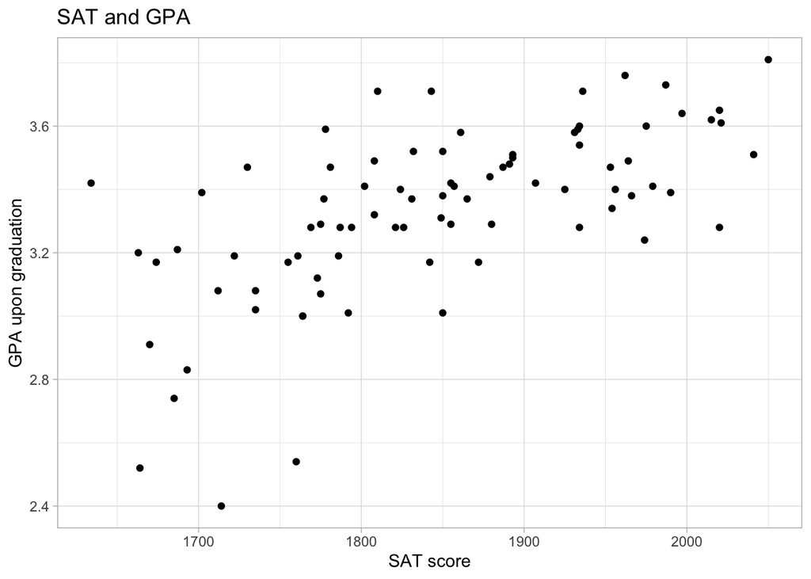

```r
# We will create a linear regression which:
# predicts the GPA of a student based on their SAT score.

#To build a linear model we need lm() function and precisely two arguments.
#1: The formula we are using
#2: The data R must operate on

linearmod <- lm(GPA ~ SAT, data=collage)

ggplot(collage, aes(x=SAT, y=GPA))+
  geom_point()+
  theme_light()+
  labs(x="SAT score",
       y="GPA upon graduation",
       title = "SAT and GPA")
```

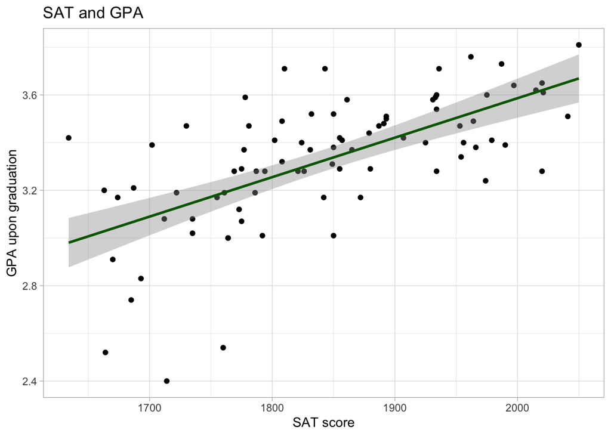

```r
# Observing the data, it is clear that:
# There is a strong relationship between SAT score and GPA.

# Let's plot the regression line on the scatter plot.
# The line which is the closest to all observations simultaneously.

ggplot(collage, aes(x=SAT, y=GPA))+
  geom_point()+
  theme_light()+
  labs(x="SAT score",
       y="GPA upon graduation",
       title = "SAT and GPA")+
stat_smooth(method = "lm", se=TRUE, color="darkgreen", formula = y~x)
```

- We want 3 main things about a linear regression model.
1. The equation
2. Significance
3. Explanatory power

```r
# We created an object called linearmod.
# And we can explore the results with summary function.

summary(linearmod)
```

```
##
## Call:
## lm(formula = GPA ~ SAT, data = collage)
##
## Residuals:
##      Min       1Q   Median       3Q      Max
## -0.71289 -0.12825  0.03256  0.11660  0.43957
##
## Coefficients:
##              Estimate Std. Error t value Pr(>|t|)
## (Intercept) 0.2750403  0.4087394   0.673    0.503
## SAT         0.0016557  0.0002212   7.487  7.2e-11 ***
## ---
## Signif. codes:  0 '***' 0.001 '**' 0.01 '*' 0.05 '.' 0.1 ' ' 1
##
## Residual standard error: 0.2106 on 82 degrees of freedom
## Multiple R-squared:  0.406,  Adjusted R-squared:  0.3988
## F-statistic: 56.05 on 1 and 82 DF,  p-value: 7.2e-11
```

```r
# There are two coefficients:
# 1) Intercept is .275 which means beta0=0.275
# 2) The second one is 0.0017 which is beta1

# The formula is; y^= 0.275+0.0017*SAT

# Std. Error shows the accuracy of the prediction for each variable.
# The lower the SE is the better the estimate.

# There is hypothesis involved here!
# HO: beta=0, (the coefficient is zero)
# If the beta0 = 0 then the line crosses the Y axis at the origin.
# If beta1=0, x*beta1=0. -->
# this variable won't be considered important for the model.
# That means graphically the regression line is horizontal.
# Essentially this test ask is x a useful variable?
# Does it help us explain the variability we have in this case?

# The answer is contained in the p value column.
# The p value 7.2e-11 means that-->
# The coefficient is most probably different from zero.

# In summary :  SAT score is significant variable when predicting collage GPA.

# However, the intercept p value is not zero. (0.503)
# This test is asking the question,
# do we have enough statistical evidence that the intercept differs from zero. # Graphically that means the regression line passes through the origin.
# On the other hand, this statistics is not so important.
# Because we are more interested in beta1.
```

- Example 2

```r
#Load the data as a tibble (readr has a function that does this directly)
reg.realty<- read_csv("real_estate_price_size_year_view.csv")
#Get the descriptive
summary(reg.realty)
```

```
##      price             size             year          view
##  Min.   :154282   Min.   : 479.8   Min.   :2006   Length:100
##  1st Qu.:234280   1st Qu.: 643.3   1st Qu.:2009   Class :character
##  Median :280591   Median : 696.4   Median :2015   Mode  :character
##  Mean   :292290   Mean   : 853.0   Mean   :2013
##  3rd Qu.:335724   3rd Qu.:1029.3   3rd Qu.:2018
##  Max.   :500681   Max.   :1842.5   Max.   :2018
```

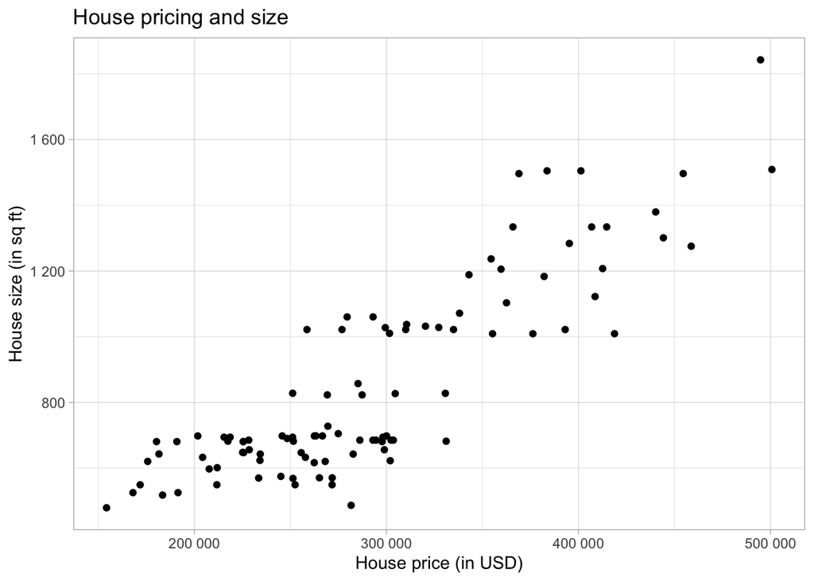

```r
# Use scales library to create a custom format when plotting the data
library(scales)
point <- format_format(big.mark = " ", decimal.mark = ",", scientific = FALSE) # this helps us get rid of the scientific notation in the graph

ggplot(reg.realty, aes(price, size)) +
  geom_point() +
  theme_light() +
  labs(x = "House price (in USD)",
       y = "House size (in sq ft)",
       title = "House pricing and size") +
  scale_x_continuous(labels = point) +
  # This is where we tell ggplot2 to use the format we set up above (point).
  # We can also use other arguments like:
  # labels=comma,
  # labels=dollar (dollar and comma are included in scales package)
  scale_y_continuous(labels = point)
```

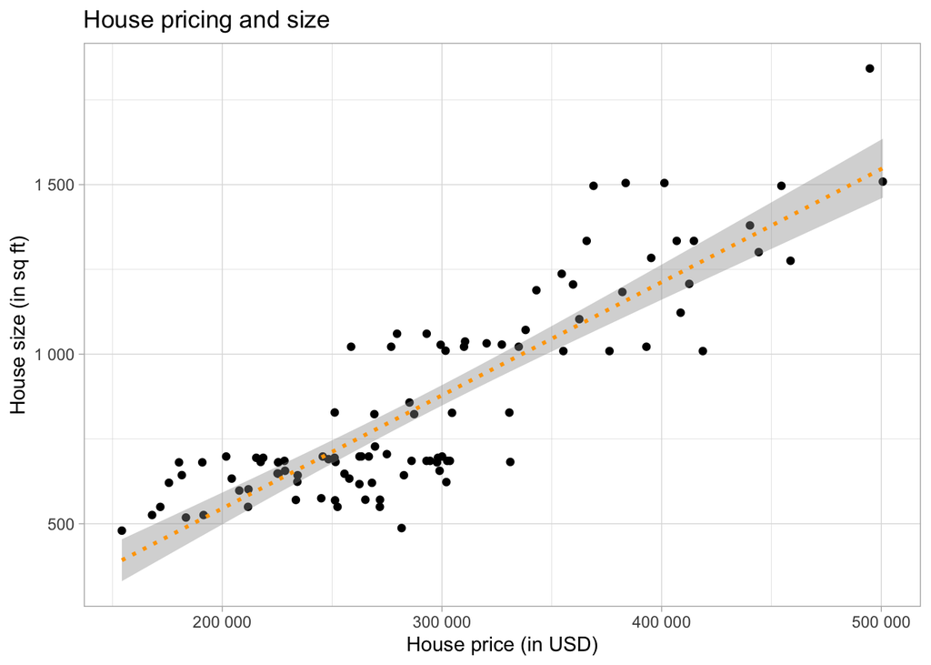

```r
#Define the linear model
price.size.lm <- lm(price~size, reg.realty)

#Plot the regression line
ggplot(reg.realty, aes(price, size)) +
  geom_point() +
  theme_light() +
  labs(x = "House price (in USD)",
       y = "House size (in sq ft)",
       title = "House pricing and size") +
  scale_x_continuous(labels = point) +
  scale_y_continuous(labels = point)+
  stat_smooth(method = "lm",
              se = TRUE,
              color="orange",
              linetype="12",
              formula = y~x)
```

```r
# Print the results of the model
summary(price.size.lm)
```

```
##
## Call:
## lm(formula = price ~ size, data = reg.realty)
##
## Residuals:
##    Min     1Q Median     3Q    Max
## -73606 -27947  -2800  30590  91597
##
## Coefficients:
##             Estimate Std. Error t value Pr(>|t|)
## (Intercept) 101912.6    11919.3    8.55 1.68e-13 ***
## size           223.2       13.2   16.91  < 2e-16 ***
## ---
## Signif. codes:  0 '***' 0.001 '**' 0.01 '*' 0.05 '.' 0.1 ' ' 1
##
## Residual standard error: 39130 on 98 degrees of freedom
## Multiple R-squared:  0.7447, Adjusted R-squared:  0.7421
## F-statistic: 285.9 on 1 and 98 DF,  p-value: < 2.2e-16
```

```r
# How many observations was the regression run on?
# Answer is : 100.
# This is evident from the degrees of freedom (residual)

# degrees of freedom (residual) is calculated -->
# based on the sample size (n) minus the number of parameters (k) being
# estimated minus 1.
# Degrees of freedom (residual) = n - k - 1 (98 = n - 1 - 1, n=100)

# What is the R-squared of this regression?
# Adjusted R-squared:  0.7421 -
# We only look at the adjusted R-squared because it is more reliable.

# The adjusted R-squared increases only -->
# If the new term improves the model more than would be expected by chance.
# It decreases when -->
# a predictor improves the model by less than expected by chance
# The value tells us that-->
# this model explains a big part of the variability in the model (~75%)
# Determine if size is a statistically significant predictor of price -->
# p value is near zero. Yes.
# What is the regression equation associated with this regression model? y^=101912.6+223.2*x1
```

- **The Standard Error of the Estimate**: The regression equation computed for any one sample of observations is only an estimate of the true population regression equation. If other samples are chosen from the population and a regression equation is calculated for each sample, these equations will vary from one sample to another with respect to both their slopes and their intercepts. An estimate of this variation is standard error of the estimate or standard error of regression. It is based on the squared deviations of the predicted y^’ s from the actual y’s.

```r
# Load the BMI-Body % Fat data
Fat_data<-data.frame(
  read.csv("Kluess-plasma DPPIV-data.csv")
  )[,c("Participant..","BMI..kg.m2.","Percent.Fat","Sex")]
colnames(Fat_data)<-c("Participant", "BMI", "Percent.Fat","Sex")
get_summary_stats(Fat_data)
```

| variable | n | min | max | median | q1 | q3 | iqr | mad | mean | sd | se | ci |
| --- | --- | --- | --- | --- | --- | --- | --- | --- | --- | --- | --- | --- |
| BMI | 111 | 17.5 | 37.1 | 23.2 | 21.1 | 25.80 | 4.70 | 3.410 | 23.804 | 3.786 | 0.359 | 0.712 |
| Participant | 111 | 1.0 | 111.0 | 56.0 | 28.5 | 83.50 | 55.00 | 41.513 | 56.000 | 32.187 | 3.055 | 6.054 |
| Percent.Fat | 111 | 7.0 | 51.2 | 29.1 | 22.7 | 33.95 | 11.25 | 7.710 | 28.343 | 8.760 | 0.831 | 1.648 |

```r
head(Fat_data)
```

|  | Participant | BMI | Percent.Fat | Sex |
| --- | --- | --- | --- | --- |
| 1 | 1 | 30.7 | 33.6 | F |
| 2 | 2 | 23.0 | 26.6 | F |
| 3 | 3 | 20.0 | 25.9 | F |
| 4 | 4 | 23.2 | 40.6 | F |
| 5 | 5 | 20.8 | 30.0 | F |
| 6 | 6 | 26.6 | 38.9 | F |

```r
summary(Fat_data)
```

```
##   Participant         BMI        Percent.Fat        Sex
##  Min.   :  1.0   Min.   :17.5   Min.   : 7.00   Length:111
##  1st Qu.: 28.5   1st Qu.:21.1   1st Qu.:22.70   Class :character
##  Median : 56.0   Median :23.2   Median :29.10   Mode  :character
##  Mean   : 56.0   Mean   :23.8   Mean   :28.34
##  3rd Qu.: 83.5   3rd Qu.:25.8   3rd Qu.:33.95
##  Max.   :111.0   Max.   :37.1   Max.   :51.20
```

```r
# Create linear model and get summary
regressor<-lm(Percent.Fat~BMI, data = Fat_data)
summary(regressor)
```

```
##
## Call:
## lm(formula = Percent.Fat ~ BMI, data = Fat_data)
##
## Residuals:
##     Min      1Q  Median      3Q     Max
## -21.126  -3.875   1.262   5.564  12.927
##
## Coefficients:
##             Estimate Std. Error t value Pr(>|t|)
## (Intercept)   5.1539     4.8438   1.064     0.29
## BMI           0.9742     0.2010   4.847 4.18e-06 ***
## ---
## Signif. codes:  0 '***' 0.001 '**' 0.01 '*' 0.05 '.' 0.1 ' ' 1
##
## Residual standard error: 7.982 on 109 degrees of freedom
## Multiple R-squared:  0.1773, Adjusted R-squared:  0.1698
## F-statistic: 23.49 on 1 and 109 DF,  p-value: 4.181e-06
```

```r
# Standard error of the estimate : 7.982

# :::::: Inferences About Intercept ::::::
# Test the hypothesis: intercept departs significantly from zero
# H0: ß1 = 0 (The intercept is zero)
# H1: ß1 ≠ 0 (The intercept is not zero)
# As evident from the summary of linear model,
# The value of the t distribution with 109 (df=111-2) df that
# divides the area into the central 95% and the combined upper and lower 5%-->
# is approximately 1.98.
# The absolute value of the observed t ratio is 1.06.
# Which is not greater than 1.98.
# The null hypothesis of a zero intercept i5 therefore not rejected.
# The evidence is insufficient to show that -->
# the intercept is significantly different from zero.

# :::::: Inferences about the Regression Coefficient ::::::
# BMI Coefficient p<0.0001
# The evidence is sufficient to show that -->
# the coefficient is significantly different from zero.

# :::::: Conf intervals for Intercept and regression coefficient ::::::
confint(regressor, level = 0.95)
```

```
##                  2.5 %    97.5 %
## (Intercept) -4.4463707 14.754181
## BMI          0.5758458  1.372543
```

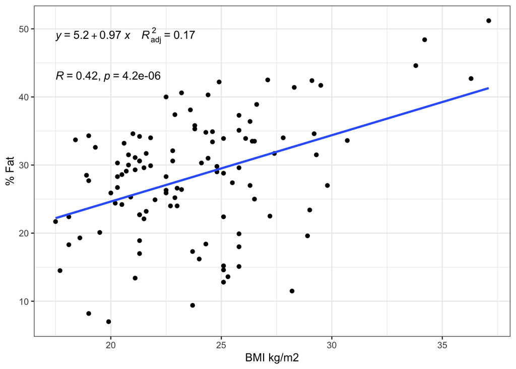

```r
# Confidence interval also covers 0 for intercept.
# BMI coefficient interval excludes zero.
# We can be 95% confident that the regression coefficient is not zero but -->
# that it is between 0.57 and 1.37.


# Visualize with ggplot and,
# 1. Add regression equations in the plot with ggpubr
# 2. Add correlation coefficient and p value
ggplot(data=Fat_data, aes(x=BMI,y=Percent.Fat))+
  geom_point()+
  xlab("BMI kg/m2")+
  ylab("% Fat")+
  theme_bw()+
  stat_smooth(formula=y~x, method = "lm", se=FALSE)+
  ggpubr::stat_regline_equation(aes(label=paste(..eq.label..,
                                                ..adj.rr.label..,
                                                sep = "~~~~")),
                                formula = y~x)+
  ggpubr::stat_cor(label.y = 43)
```

- Predicting with the regression equation

```r
# Create a test data

Test_data<-data.frame(BMI=c(19.3,20.0,20.8,21.0,23.0,23.20,
                            25.80,26.60,27.80,30.70,23.80),
                      Percent.Fat=c(32.6,25.9,30.0,34.6,
                                    26.6,40.6,37.3,38.9,34.0,
                                    33.6,35.3))
Test_data
```

| BMI | Percent.Fat |
| --- | --- |
| 19.3 | 32.6 |
| 20.0 | 25.9 |
| 20.8 | 30.0 |
| 21.0 | 34.6 |
| 23.0 | 26.6 |
| 23.2 | 40.6 |
| 25.8 | 37.3 |
| 26.6 | 38.9 |
| 27.8 | 34.0 |
| 30.7 | 33.6 |

[output cut: 1 more lines]

```r
# Predict values
predicted_values <- predict.lm(object = regressor,
                               newdata = select(Test_data, BMI),
                               se.fit = TRUE, interval = "confidence",
                               level = 0.95)
predicted_values
```

```
## $fit
##         fit      lwr      upr
## 1  23.95586 21.61643 26.29528
## 2  24.63779 22.50468 26.77090
## 3  25.41715 23.49725 27.33705
## 4  25.61199 23.74070 27.48328
## 5  27.56038 26.02515 29.09560
## 6  27.75522 26.23460 29.27583
## 7  30.28812 28.58904 31.98721
## 8  31.06748 29.19790 32.93705
## 9  32.23651 30.04818 34.42484
## 10 35.06167 31.93096 38.19239
## 11 28.33973 26.83825 29.84122
##
## $se.fit
##         1         2         3         4         5         6         7         8
## 1.1803540 1.0762590 0.9686840 0.9441566 0.7745976 0.7672238 0.8572720 0.9432928
##         9        10        11
## 1.1041194 1.5796009 0.7575720
##
## $df
## [1] 109
##
## $residual.scale
## [1] 7.981513
```

```r
# Combine predicted values with original observations.
sum.table <-cbind(Test_data,
                  predicted_values$fit,
                  SE=predicted_values$se.fit )
head(sum.table)
```

|  | BMI | Percent.Fat | fit | lwr | upr | SE |
| --- | --- | --- | --- | --- | --- | --- |
| 1 | 19.3 | 32.6 | 23.95586 | 21.61643 | 26.29528 | 1.1803540 |
| 2 | 20.0 | 25.9 | 24.63779 | 22.50468 | 26.77090 | 1.0762590 |
| 3 | 20.8 | 30.0 | 25.41715 | 23.49725 | 27.33705 | 0.9686840 |
| 4 | 21.0 | 34.6 | 25.61199 | 23.74070 | 27.48328 | 0.9441566 |
| 5 | 23.0 | 26.6 | 27.56038 | 26.02515 | 29.09560 | 0.7745976 |
| 6 | 23.2 | 40.6 | 27.75522 | 26.23460 | 29.27583 | 0.7672238 |

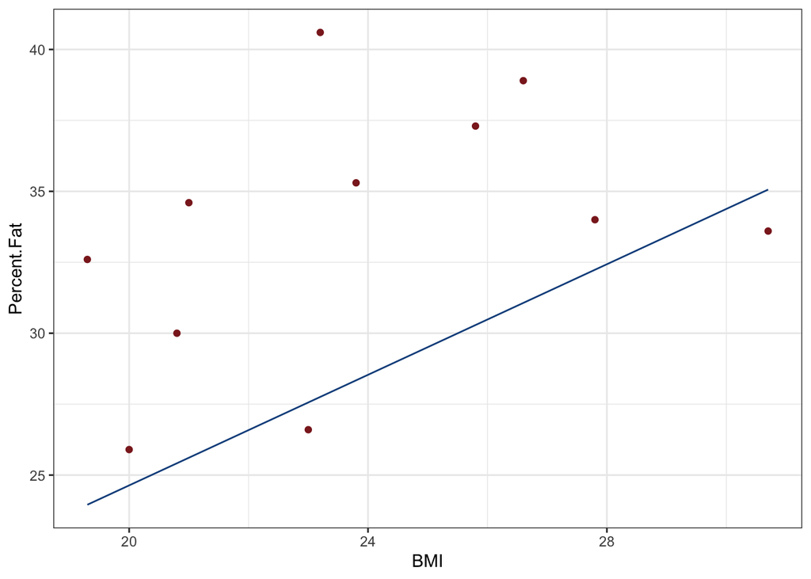

```r
# Visualize

ggplot(data = sum.table) +
  geom_point(aes(x = BMI, y = Percent.Fat),
             colour = 'brown4') +
  geom_line(aes(x = BMI, y = fit),
            colour = 'dodgerblue4')+
  theme_bw()
```

## 3.2 Decomposition of varaiability: SST,SSR,SSE

- Determinants of good regression
- There are 3 terms:
1. **Sum of squares total (SST)(TSS)**: is the squared differences between the observed dependent variable and it’s mean. Much like the variance. It is the measure of total variability of the data set. Also known as total sum of squares, TSS.

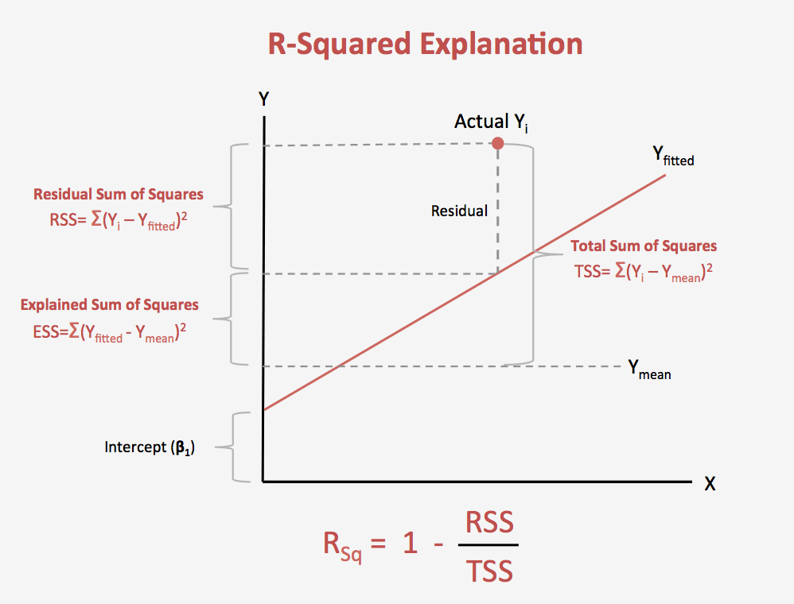

Summary of the terms described.

2. **Sum of squares regression (SSR), Sum of Squares Explained** : It is the sum of the differences between the predicted value in the mean of the dependent variable. It is a measure that describes how well your line fits the data. If **SSR=SST**, it means that our regression model captures all the observed variability, and it is perfect. Other notation is ESS, explained sum of squares.

3)**Sum of squares error(SSE)**: smaller is better, also called RSS, residual sum of squares. SSE measures the unexplained variability by the regression.

- So the mathematical equation is:

$SS_{explained}=SS_{total}-SS_{residual}$

- Total variability of the data set is equal to the variability explained by the regression line plus the unexplained variability known as error. Given a constant total variability, a lower error will cause a better regression. If SSE is closer to zero, explained sum of square move closer to SST. Higher error will cause a less powerful regression.

$\sum_{i=1}^n (y_i-\overline y)^2 = \sum_{i=1}^n (\hat y_i-\overline y)^2 + \sum_{i=1}^n e_i^2$

## 3.3 R-squared

- There is one widely used measure that describes **how powerful a regression** is : R squared

$R^2 = 1- \dfrac{SS_{residual}}{SS_{Total}}$

- R squared is equal to variability explained by the regression is divided by the total variability of the data set.
- R squared is ranging 0-1. But also can be negative. Mostly (.2-.9) R squared=0 means the regression analysis explains none of the variability of the data. R squared=1 means the regression model explains the entire variability of the data.